# Extending `dynardl` to estimate model in first-differences w/o lagged DV

In Philips, A. Q. (2018, American Journal of Political Science, 62(1), 230-244), present a flow chart of which model to estimate, as a function of the time series properties of the dependent and independent variables (see Figure 1, p. 233).

The existing `dynardl` package can estimate two out of the three models:

1. Estimate ARDL(p,q) in levels (case j) –> specify `dynardl` with `EC = FALSE`
2. Conclude cointegration and estimate ARDL(p,q) in error-correction form (case o) –> specify `dynardl` with `EC = TRUE`

The last case is not covered yet, namely:

3. First-difference dependent variable and run ARDL(p,q) (case r). That would require to estimate `dynardl` with `EC = TRUE`, but to NOT automatically add the lagged dependent variable to the model (cf. formula 11 in Philips 2018, p. 234).

Below, I illustrate an extension to `dynardl` that covers that case.

Let us first simulate some data for different values of the coefficient of the lagged dependent variable, `phi = -.8` and `phi = 0`.

```r
# Load prototype of package
library(devtools)
load_all('../R')
```

```r
# Simulate data for different values of phi

set.seed(1)
my_data <- lapply(c(-.8, 0), function(phi) {
  x.error <- rnorm(500, 0, 2)
  x.full <- x.error
  y.error <- rnorm(500, 0, 2)
  y.full <- y.error
  y.diff.full <- rep(NA, length(y.full))
  #phi <- 0 #-0.8 # coef on ldv
  beta.lx <- 1 # coef on l.x
  beta.diff.x <- -2 # coef on x


  for(i in 2:length(x.full)) {
    x.full[i] <- x.full[i - 1] + x.error[i]
    y.diff.full[i] <- phi*y.full[i - 1] + beta.diff.x*(x.full[i] - x.full[i - 1]) + beta.lx*x.full[i - 1] + y.error[i] # rnorm(1, 0, 1) + const*rnorm(1, 1, 0.25) +
    y.full[i] <- y.full[i - 1] + y.diff.full[i]
  }

  # Trim the burn in
  x <- x.full[101:500]
  y.diff <- y.diff.full[101:500]
  y <- y.full[101:500]

  return(data.frame(x=x,y=y))
})
```

```r
# Let us also introduce a function that easily allows us to plot the simulation result of dynardl

plot_dynardl <- function(model) {
  par(mfrow = c(1, 4))
  plot(y, type = "l")
  plot(dshift(y), type = "l")
  dynardl.simulation.plot(model, response = "diffs")
  dynardl.simulation.plot(model, response = "levels")
}
```

# Estimate case (2): ARDL(p,q) in error correction form

```r
############################################
# Lagged DV present: use data w/ phi = -.8 #
############################################

# the default: adds lagged dependent variable if specified with ec = TRUE
set.seed(1)
x=my_data[[1]]$x
y=my_data[[1]]$y

model.ec <- dynardl(y ~ x, lags = list("x" = c(1)), diffs = c("x"),
                    simulate = TRUE, fullsims = TRUE,
                    shockvar = "x",
                    sims = 10000, range = 20,
                    ec = TRUE)
```

```
## [1] "Error correction (EC) specified; dependent variable to be run in differences."
## [1] "x shocked by one standard deviation of x by default."
## [1] "dynardl estimating ..."
##
```

```r
summary(model.ec)
```

```
##
## Call:
## lm(formula = as.formula(paste(paste(dvnamelist), "~", paste(colnames(IVs),
##     collapse = "+"), collapse = " ")))
##
## Residuals:
##     Min      1Q  Median      3Q     Max
## -5.6953 -1.4691  0.0963  1.4356  5.9795
##
## Coefficients:
##             Estimate Std. Error t value Pr(>|t|)
## (Intercept) -0.53608    0.28964  -1.851   0.0649 .
## l.1.y       -0.79076    0.01499 -52.745   <2e-16 ***
## d.1.x       -2.02028    0.05251 -38.475   <2e-16 ***
## l.1.x        1.00906    0.02137  47.216   <2e-16 ***
## ---
## Signif. codes:  0 '***' 0.001 '**' 0.01 '*' 0.05 '.' 0.1 ' ' 1
##
## Residual standard error: 2.162 on 395 degrees of freedom
##   (1 observation deleted due to missingness)
## Multiple R-squared:  0.9187, Adjusted R-squared:  0.9181
## F-statistic:  1489 on 3 and 395 DF,  p-value: < 2.2e-16
```

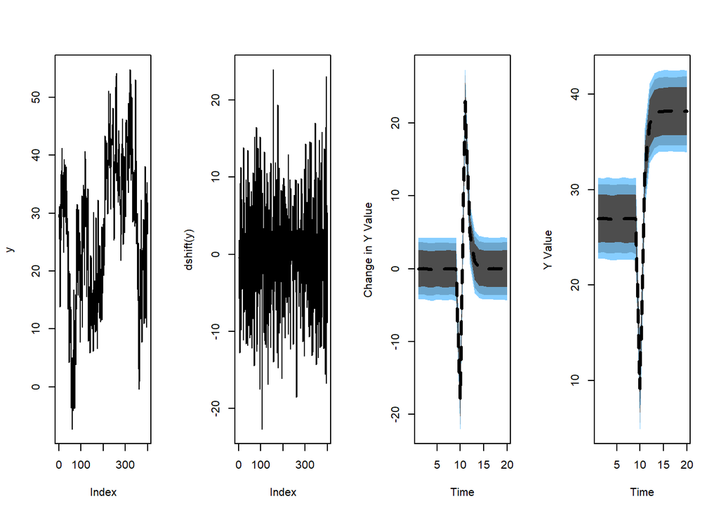

```r
plot_dynardl(model.ec)
```

Let us now turn to a case in which we do not want to estimate that coefficient for the lagged DV.

# Estimate case (3): ARDL(p,q) in first-differences

## Restricting the coefficient of the lagged DV to zero is not possible

```r
##############################################
# Lagged DV not present: use data w/ phi = 0 #
##############################################

# re-estimate w/ EC = T
set.seed(1)
x=my_data[[2]]$x
y=my_data[[2]]$y

model.ec2 <- dynardl(y ~ x, lags = list("x" = c(1)), diffs = c("x"),
                    simulate = TRUE, fullsims = TRUE,
                    shockvar = "x",
                    sims = 10000, range = 20,
                    ec = TRUE)
```

```
## [1] "Error correction (EC) specified; dependent variable to be run in differences."
## [1] "x shocked by one standard deviation of x by default."
## [1] "dynardl estimating ..."
##
```

```r
summary(model.ec2)
```

```
##
## Call:
## lm(formula = as.formula(paste(paste(dvnamelist), "~", paste(colnames(IVs),
##     collapse = "+"), collapse = " ")))
##
## Residuals:
##     Min      1Q  Median      3Q     Max
## -5.3064 -1.3307 -0.0413  1.5446  6.4952
##
## Coefficients:
##               Estimate Std. Error t value Pr(>|t|)
## (Intercept)  4.060e-01  3.529e-01   1.151    0.251
## l.1.y        6.250e-05  8.014e-05   0.780    0.436
## d.1.x       -2.011e+00  5.400e-02 -37.244   <2e-16 ***
## l.1.x        1.021e+00  7.972e-03 128.093   <2e-16 ***
## ---
## Signif. codes:  0 '***' 0.001 '**' 0.01 '*' 0.05 '.' 0.1 ' ' 1
##
## Residual standard error: 2.139 on 395 degrees of freedom
##   (1 observation deleted due to missingness)
## Multiple R-squared:  0.9823, Adjusted R-squared:  0.9821
## F-statistic:  7294 on 3 and 395 DF,  p-value: < 2.2e-16
```

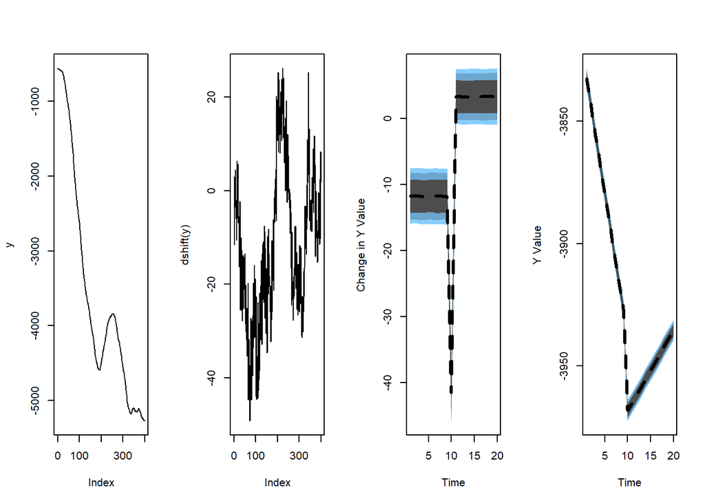

```r
plot_dynardl(model.ec2)
```

Observe again that `dynardl` automatically adds the lagged dependent variable to the model. While the parameters are recovered reasonably well (coefficient on l.1.y is small and not significant), this is undesirable if one wishes to restrict the coefficient on the lagged DV to zero.

## Introducing a new option: ec_enforce_lagged_dv to restrict the coefficient on the lagged DV to zero

```r
# re-estimate w/ EC = 2, but DO NOT estimate coefficient for l.1.y
# this model mimicks formula (11) in Philips 2018, American J of Political Science, p. 234.

set.seed(1)
x=my_data[[2]]$x
y=my_data[[2]]$y

model.ec.nlag <- dynardl(y ~ x, lags = list("x" = c(1)), diffs = c("x"),
                    simulate = T, fullsims = TRUE,
                    shockvar = "x",
                    sims = 10000, range = 20,
                    ec = TRUE, ec_enforce_lagged_dv = F)
```

```
## [1] "Error correction (EC) specified; dependent variable to be run in differences."
## [1] "x shocked by one standard deviation of x by default."
## [1] "dynardl estimating ..."
##
```

```r
summary(model.ec.nlag)
```

```
##
## Call:
## lm(formula = as.formula(paste(paste(dvnamelist), "~", paste(colnames(IVs),
##     collapse = "+"), collapse = " ")))
##
## Residuals:
##     Min      1Q  Median      3Q     Max
## -5.3191 -1.3581 -0.0513  1.5340  6.4789
##
## Coefficients:
##             Estimate Std. Error t value Pr(>|t|)
## (Intercept)  0.15235    0.13683   1.113    0.266
## d.1.x       -2.01750    0.05335 -37.818   <2e-16 ***
## l.1.x        1.01865    0.00727 140.121   <2e-16 ***
## ---
## Signif. codes:  0 '***' 0.001 '**' 0.01 '*' 0.05 '.' 0.1 ' ' 1
##
## Residual standard error: 2.138 on 396 degrees of freedom
##   (1 observation deleted due to missingness)
## Multiple R-squared:  0.9822, Adjusted R-squared:  0.9822
## F-statistic: 1.095e+04 on 2 and 396 DF,  p-value: < 2.2e-16
```

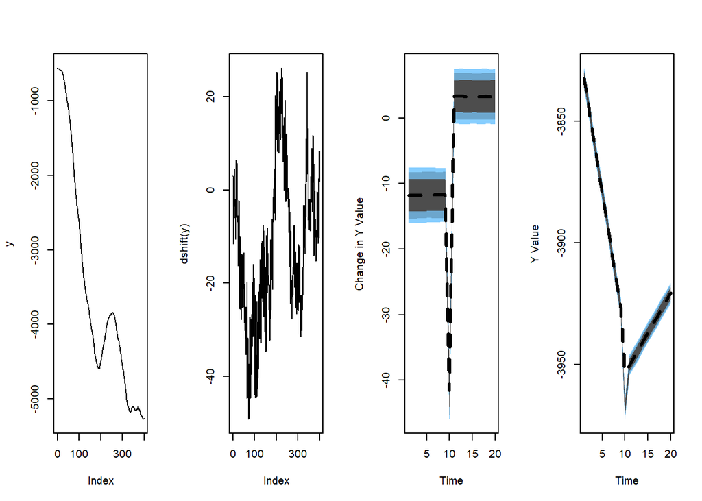

```r
plot_dynardl(model.ec.nlag)
```

Observe that:

- parameters are recovered well, and
- plots look reasonably well